## Problem 6

*Chapter 6, Exercise 10 (p. 263)*

> We have seen that as the number of features used in a model increases, the training error will necessarily decrease, but the test error may not. We will now explore this in a simulated data set.

#### Part A

> Generate a data set with `p = 20` features, `n = 1000` observations, and an associated quantitative response vector generated according to the model `Y = Xβ + ε`, where `β` has some elements that are exactly equal to `0`.

```r
set.seed(19)  # Some randomization in the setup.

p = 20
n = 1000

X = matrix(rnorm(p * n), ncol = p, nrow = n)

# Randomly set some elements in beta equal to zero.
beta              = rnorm(p, sd = 10)
num_rand_zeroes   = sample(0:p/3)
rand_zeroes       = sample(seq(1, length(beta)), num_rand_zeroes, replace = F)
beta[rand_zeroes] = 0

e = rnorm(n)
Y = as.vector(X * beta + e)
```

#### Part B

> Split your data set into a training set containing `100` observations and a test set containing `900` observations.

```r
n_training_observations = 100
train   = sample(1:nrow(X), n_training_observations)
test    = (-train)

X.train = X[train]
Y.train = Y[train]
X.test  = X[test ]
Y.test  = Y[test ]

df.train = data.frame(y = Y.train, x = X.train)
df.test  = data.frame(y = Y.test,  x = X.test)
```

#### Part C

> Perform best subset selection on the training set, and plot the training set MSE associated with the best model of each size.

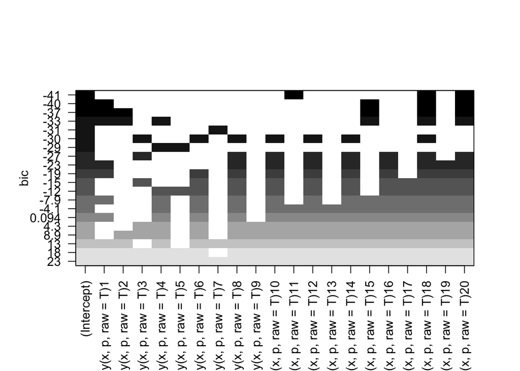

```r
library(leaps)
fit      = regsubsets(y ~ poly(x, p, raw = T), data = df.train, nvmax = p)

plot(fit)
```

#### Part D

> Plot the test set MSE associated with the best model of each size.

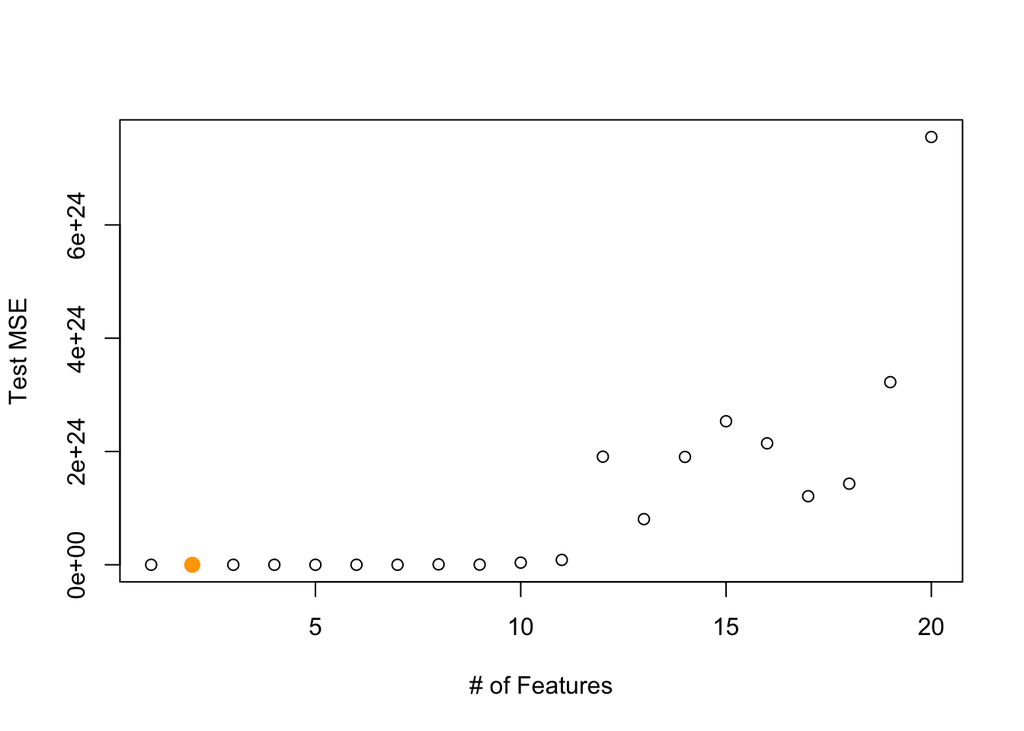

```r
mse = function(prediction, real) {
  mean((prediction - real)^2)
}

predict_regsubsets = function(obj, newdata, id) {
  form   = as.formula(obj$call[[2]]) # Extract formula.
  matrix = model.matrix(form, newdata)
  coefic = coef(obj, id = id)
  xvars  = names(coefic)
  matrix[, xvars] * coefic
}

test.mse = sapply(1:p, function(id) {
  prediction = predict_regsubsets(fit, df.test, id)
  mse(prediction, Y.test)
})

plot(seq(1:p), test.mse, xlab = '# of Features', ylab = 'Test MSE')
points(which.min(test.mse), test.mse[which.min(test.mse)], col = 'orange', cex = 2, pch = 20)
```

```r
coef(fit, id = which.min(test.mse))
```

```
##          (Intercept) poly(x, p, raw = T)4 poly(x, p, raw = T)5
##           -1.0638214            0.1926629           -0.2965513
```

#### Part E

> For which model size does the test set MSE take on its minimum value? Comment on your results. If it takes on its minimum value for a model containing only an intercept or a model containing all of the features, then play around with the way that you are generating the data in (a) until you come up with a scenario in which the test set MSE is minimized for an intermediate model size.

The test MSE is low and approximately constant from 0-11 features. After that, it shoots up. This is expected – since we set beta to `0` for some of the features, it’s better to simply throw those out of our model since they don’t provide any information.

#### Part F

> How does the model at which the test set MSE is minimized compare to the true model used to generate the data? Comment on the coefficient values.

The test MSE is low until we begin to include the features whose beta values are `0`. This makes sense and matches the reality of our model.

#### Part G

> Create a plot displaying $\sqrt{ \sum_{j=1}^{p} \Big(\beta_j - \hat{\beta_j^{r}} \Big)^{2} }$ for a range of values of `r`, where $\hat{\beta_j^{r}}$ is the `j`th coefficient estimate for the best model containing `r` coefficients. Comment on what you observe. How does this compare to the test MSE plot from (d)?

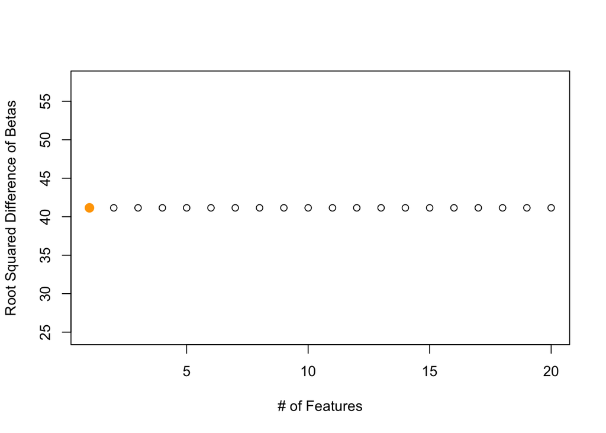

```r
rsqdiffs = sapply(1:p, function(r) {
  coefics    = coef(fit, id = r)
  coef_names = names(coefics)
  beta.est   = sapply(1:p, function(i) {
    id = sprintf('Feature #%d', i)
    if (id %in% coef_names) {
      return(coefics[id])
    } else return(0)
  })
  return(sqrt( sum((beta - beta.est)^2)) )
})

plot(seq(1:p), rsqdiffs, xlab = '# of Features', ylab = 'Root Squared Difference of Betas')
points(which.min(rsqdiffs), rsqdiffs[which.min(rsqdiffs)], col = 'orange', cex = 2, pch = p)
```

All possibilities of `k` features have approximately the same Root Squared Difference of Betas.